# Assignment 5

### Question 13: Networks: Pick a (lead) actor who has been in at least 20 movies. Find all of the other actors that have appeared in a movie with that person. For each of these, find all the people they have appeared in a movie with. Use this to create a network/graph of who has appeared with who.

```r
# for actor Andrew Garfield, he appeared in 53 movies (movies only
# excluding TV series); however, IMDB also includes award shows such
# as Much Music Video Music Awards andFilm Independent SPirit Awards
# as a movie
# To get all the second and third degree matches for Andrew Garfield,
# I had to first find all the movies that he has been in. Next I find
# all the people who have been in the same movies as him and this can be
# done by finding all the actors who have been in the same movie ID (easier
# than finding the actors by movie names/title). This is done by checking the
# same tables again and getting the first and last names of the actors. Since
# I cannot INNER JOIN the same table names repeated in a single query, I
# renamed the tables to actors2, acted_in2, series2 and movies2. To find
# people who are three degrees away from Andrew Garfield, I do the same
# thing as I did for finding the people who are two degrees from Andrew
# Garfield, instead I change all the 2's to 3's. Next I filtered my results
# by removing all the movies/TV shows with a series ID and only took actors
# that had a billing position of 1, 2 or 3. To remove NA's from my table,
# I set the actor's lname to IS NOT NULL. Then I ordered my table my movie ID.
actedWithDF = dbGetQuery(con, "SELECT actors.lname ||', '||actors.fname 'First Degree',
                         actors2.lname ||', '||actors2.fname 'Second Degree',
                         actors3.lname ||', '||actors3.fname 'Third Degree'
                         FROM actors
                         INNER JOIN acted_in
                         ON actors.idactors = acted_in.idactors
                         INNER JOIN movies
                         ON acted_in.idmovies = movies.idmovies
                         LEFT JOIN series
                         ON series.idmovies = movies.idmovies
                         INNER JOIN actors actors2
                         ON acted_in2.idactors = actors2.idactors
                         INNER JOIN acted_in acted_in2
                         ON movies.idmovies = acted_in2.idmovies
                         INNER JOIN movies movies2
                         ON acted_in2.idmovies = movies2.idmovies
                         LEFT JOIN series series2
                         ON series2.idmovies = movies2.idmovies
                         INNER JOIN actors actors3
                         ON acted_in3.idactors = actors3.idactors
                         INNER JOIN acted_in acted_in3
                         ON movies2.idmovies = acted_in3.idmovies
                         WHERE series.idmovies IS NULL
                         AND series2.idmovies IS NULL
                         AND acted_in2.billing_position <= 3
                         AND acted_in3.billing_position <= 3
                         AND LOWER(actors.fname) = 'andrew'
                         AND LOWER(actors.lname) = 'garfield'
                         AND actors2.lname IS NOT NULL
                         AND actors3.lname IS NOT NULL
                         ORDER BY movies.idmovies")
```

```r
# get all the matches with the first degree and second degree, so remove
# the third column by setting it to null
firstDegree = actedWithDF
firstDegree$`Third Degree` = NULL

# get all the matches with the second degree and third degree,
# so remove the first column by setting it to null
secondDegree = actedWithDF
secondDegree$`First Degree` = NULL

# rename the first columns in the data frame firstDegree
# and secondDegree to 'first' in order to rbind() them
colnames(firstDegree)[1] = colnames(secondDegree)[1] = 'first'
# rename the second columns in the data frame firstDegree and
# secondDegree to 'second' in order to rbind() them
colnames(firstDegree)[2] = colnames(secondDegree)[2] = 'second'
```

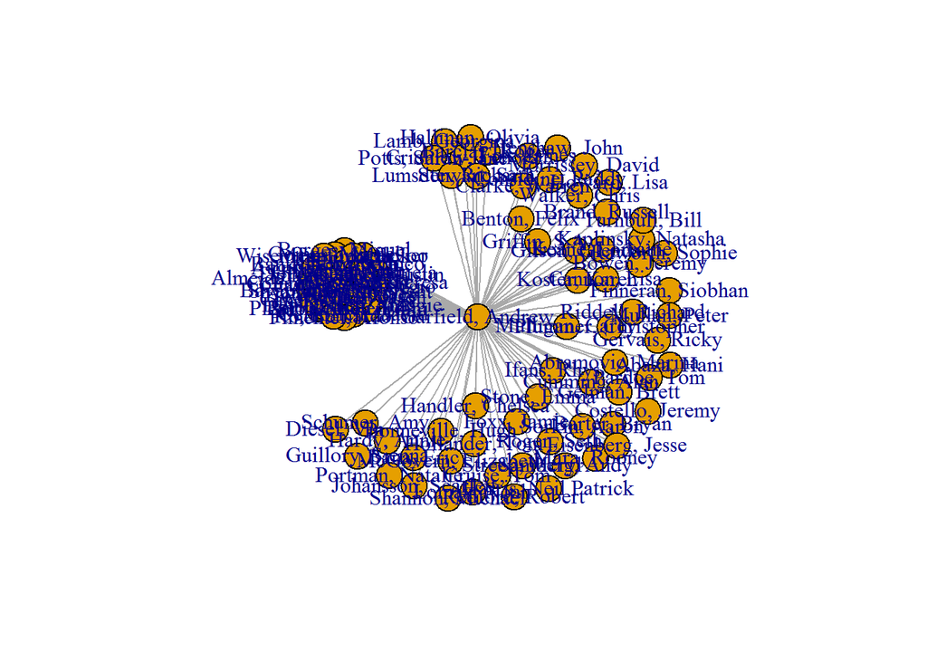

```r
library(igraph)
#row bind (stack them from tail to head/head to tail) them so
# now we only have two columns, but have all the possible pairs
# between first & second degree and second & third degree
getAllMatches = graph.data.frame(rbind(firstDegree, secondDegree), directed = FALSE)
# use the function simplify to remove all duplicate matches
question11Graph = plot(simplify(getAllMatches))
```

Since igraph only plots matches by pairs, it completely ignored my third column (three degrees away from Garfield). So in order for igraph to plot all the matches, I created two data frames with the first & second degrees and second & third degrees. Then I renamed the columns so both data frames had the same column names or else I can’t rbind() them. Finally stacked these from tail to head/head to tail by using rbind() and now I have all the matches in two columns.

There are many duplicate matches when I run rbind(firstDegree, secondDegree) because, for example, let’s say we have an actor called Main and in the second degree matches, we have Samual Jackson and Jackson has been in a movie with Scarlett Johansson and Chris Evans, which are three degrees away from Main. So this means we will have many matches that look like this: Main – Samual Jackson – Scarlett Johansson; Main – Samual Jackson – Chris Evans. So this means we will have many first and second degree matches that look like: Main – Samual Jackson; Main – Samual Jackson because of all the different third degree matches. Using simplify() will help remove multiple matches/lines on the graph and will help make the graph look cleaner and less convoluted with lines that go back and forth between the same two people.

In my igraph, Garfield is in the center since he is first degree (according to Wiki, a Bacon number of 0). We can see all the second degrees (Bacon Number 1) connection Garfield has and some of his second degree connections are connected to his other connections, which are likely Garfield’s third degree (Bacon Number 2) connection. Since I filtered my result to only have actors with billing position to 1, 2 or 3 (Duncan said on Piazza we can do this), not all the billing information was stored in IMDB (or there was no billing info) so this is why it may appear like the igraph is small even though there are much more actors in the movies than seen on the igraph. There is a giant cluster of names all group together, I am guessing it is because most of those movie actors are connected to each other in a way and are all connected to Garfield.

### Question 14: What are the 10 television series that have the most number of movie stars appearing in the shows?

Here is my attempt at 14. It doesn’t work. When I ran the query, I let it run for 6 hours and it was still going, so I stopped it. I had to comment it out or else it would not knit (or rather it would take forever to knit).

```r
# dbGetQuery(con, "SELECT name,
#            COUNT(DISTINCT(idactors))
#            FROM (SELECT series.name, acted_in.idactors
#            FROM acted_in
#            INNER JOIN series
#            ON series.idseries = series.idseries
#            INNER JOIN acted_in acted_in_movies
#            ON acted_in.idactors = acted_in_movies.idactors
#            INNER JOIN movies
#            ON acted_in_movies.idmovies = movies.idmovies
#            LEFT JOIN series series_movies
#            ON series_movies.idmovies = movies.idmovies
#            WHERE series_movies.idmovies IS NULL
#            GROUP BY series.idseries, acted_in.idactors)
#            GROUP BY name
#            ORDER BY COUNT(DISTINCT(idactors))
#            DESC
#            LIMIT 10")
```

I think some possible TV series that may have the most number of movie stars appear in the shows are: Saturday Night Live are Celebrity Name Game

### Code Appendix

```r
library(RSQLite)
con = dbConnect(SQLite(), "imdb_data")
dbListTables(con)
# get the amount of unique actors from the column idactors. SELECT the column idactors,
# but get only the unique values and COUNT all the values FROM the table actors
dbGetQuery(con, "SELECT DISTINCT COUNT(idactors) FROM actors")
# get the amount of movies. SELECT the column idmovies and COUNT all the non-null values.
# LEFT JOIN series ON series.idmoves IS NULL so that way I can filter out all the TV series.
# I only want the movies.type = 3 because thats where the movies are.
dbGetQuery(con, "SELECT
           COUNT(movies.idmovies)
           FROM movies
           LEFT JOIN series
           ON series.idmovies = movies.idmovies
           WHERE series.idmovies IS NULL
           AND movies.type = 3
           LIMIT 1")
# UNION ALL is the same as UNION but it allows duplicates
# take from table title because in table movie, the min year was 1 which is not possible
# SELECT MAX and MIN years FROM a table that has a column of years, which is taken FROM
# the table movies and the table aka_titles (since they both have a column named years),
# use UNION ALL to combine both columns, allowing duplicates. I filtered the years so it
# was restricted between 1885 and 2016 (exclusive)
dbGetQuery(con, "SELECT
           MAX(year) as 'Max Year',
           MIN(year) as 'Min Year'
           FROM(SELECT
                year
                FROM movies
                WHERE (year > 1885 AND year < 2016)
                UNION ALL
                SELECT year
                FROM aka_titles
                WHERE (year > 1885 AND year < 2016))")
# get the number of females and males
# if gender is 1, then set it to male, else set it to female, we want two
# columns called 'gender' and 'percent'. use comma to seperate the columns.
# COUNT counts the number of lines returned (if gender is NULL then set
# it to 2) / -- division (counts total number of entries in the actors table)
# / -- division 100.0 -- divides the total number of entries in the actors
# table by 100, use as 'percent' means to change the column name to percent.
# Get all this from the table actors and group them by gender
dbGetQuery(con, "SELECT
          CASE
              WHEN gender = '1'
              THEN 'male'
           ELSE 'female'
           END as 'gender',
           COUNT(
                IFNULL(gender, 2))/((SELECT COUNT(*) FROM actors)/100.0
           ) as 'percent'
           FROM actors
           GROUP BY gender")
# adult/rated X films are type 1, games are type 2, movies/TV series are type 3
# I sorted by using CASE...END and found all the movie type 1 and 2 and set them to
# different variable names, and the last one, which is type 3 will be another name.
# Next I made a column that got the percentages of each type.
dbGetQuery(con, "SELECT
           CASE
               WHEN type = '1'
               THEN 'Adult Movies'
               WHEN type = '2'
               THEN 'Video Games'
           ELSE 'Movies/TV Series'
           END as 'type',
           COUNT(type) / ((SELECT COUNT(*) FROM movies)/100.0)
           as 'percent'
           FROM movies
           WHERE type IS NOT NULL
           GROUP BY type")
# get the percentage of just movies without the TV series, and percentage of
# TV series without movies. SELECT the COUNTed rows and rename it to 'Count
# of Movies', then from there I made another column which gets the percentage
# of all the COUNT(*) and divides it by the total rows of movies/100. I filtered
# my result so it was only movies by settingseries.idmovies to NULL (so any
# movie with a series ID will be removed) and I only wanted
# movie.type = 3 since type 1 and 2 are rated X files and video games
dbGetQuery(con, "SELECT
           COUNT(*) as 'Count of Movies',
           (SELECT
           COUNT(*)
           FROM movies) as 'Total',
           COUNT(*) / ((SELECT COUNT(*) FROM movies)/100.0) as 'Percent'
           FROM movies
           LEFT JOIN series
           ON movies.idmovies = series.idmovies
           WHERE series.idmovies IS NULL
           AND movies.type = '3'")
# get the all the genres in the database by SELECTing the column genre
# (renamed to 'Genres') FROm the table genres
genres = dbGetQuery(con, "SELECT genre 'Genres' FROM genres")
genres
# SELECT the columns idgenres and genres from genres because we want the count,
# but just the count without the name/label of the genre is not helpfull, so
# with both columns it gives us meaningful data. This done through INNER JOINing
# the tables genres and movies_genres. Then COUNT the rows idmovies_genres from
# the table movies_genres and group them by genre (from genres). Filter out the
# TV series by LEFT JOINing series and setting series.idmovies to NULL and get
# only the movies.type = 3. Decending, meaning the next number is smaller,
# and get the first 10
dbGetQuery(con, "SELECT movies_genres.idgenres 'Genre ID', genres.genre 'Genre Discription',
           COUNT(*) 'Total'
           FROM movies_genres
           INNER JOIN genres
           ON movies_genres.idgenres = genres.idgenres
           INNER JOIN movies
           ON movies.idmovies = movies_genres.idgenres
           LEFT JOIN series
           ON series.idmovies = movies.idmovies
           WHERE series.idmovies IS NULL
           AND movies.type = 3
           GROUP BY genres.genre
           ORDER BY
           COUNT(*)
           DESC
           LIMIT 10")
# get the number of movies with the keywords space (with anything following
# or before the word space). This is done by getting the COUNT of movies ID
# through INNER JOIN of the tables keywords and movies_keywords ON the key
# column idkeywords. Filtered out the movies with a series ID by doing a
# LEFT JOIN on movies and series ON the key column idmovies and
# set series.idmovies to NULL and get only the rows with movies.type = 3.
dbGetQuery(con, "SELECT
           COUNT(movies_keywords.idmovies) 'Number Of Movies With Keyword space'
           FROM keywords
           INNER JOIN movies_keywords
           ON keywords.idkeywords = movies_keywords.idkeywords
           INNER JOIN movies
           ON movies.idmovies = movies_keywords.idmovies
           LEFT JOIN series
           ON movies.idmovies = series.idmovies
           WHERE series.idmovies IS NULL
           AND movies.type = 3
           AND LOWER(keywords.keyword)
           LIKE 'space'")
# get the years, this is done by SELECTing the year column from INNER JOINing
# the tables keywords and movies_keywords on the key column idkeywords. Next
# I do another INNER JOIN on the tables movies and movies_keywords on the key
# column idmovies. This is needed so I can get to the table with the years that
# are also connected to the tables keywords and movies_keywords. Next I filtered
# my result to remove the Tv series and only the movie.type = 3.Next I looked for
# keywords that are LIKE space. Finally I GROUPed BY year so I can get only
# the unique years.
dbGetQuery(con, "SELECT movies.year 'Year'
           FROM keywords
           INNER JOIN movies_keywords
           ON keywords.idkeywords = movies_keywords.idkeywords
           INNER JOIN movies
           ON movies.idmovies = movies_keywords.idmovies
           LEFT JOIN series
           ON movies.idmovies = series.idmovies
           WHERE series.idmovies IS NULL
           AND movies.type = 3
           AND year IS NOT NULL
           AND LOWER(keywords.keyword)
           LIKE 'space'
           GROUP BY movies.year")
# get the top 5 actors in each of those movies, this is done by  getting
# the relevent columns from the INNER JOINing of the tables actors, movies
# and movies_keywords. This is done to get the relevent columns: lname, fname,
# billing_position, titles and keywords. Next I filtered my results so the I
# only get actors with only a movie ID (no series ID), movie type of 3, have
# been in movies that have a keyword 'space' and have a billing position of 5
# or less. Then I GROUPed by the actor's lname and fname (or else I will
# have repeated actor names) and then I finally ordered by the movie title then
# ordered by the billing position of the actor for that movie.
dbGetQuery(con, "SELECT actors.lname ||', '|| actors.fname 'Last Name, First Name',
           acted_in.billing_position 'Billing Postion',
           movies.title 'Movie Title', keywords.keyword 'Keyword'
           FROM actors
           INNER JOIN acted_in
           ON actors.idactors = acted_in.idactors
           INNER JOIN movies
           ON movies.idmovies = acted_in.idmovies
           INNER JOIN movies_keywords
           ON acted_in.idmovies = movies_keywords.idmovies
           INNER JOIN keywords
           ON keywords.idkeywords = movies_keywords.idkeywords
           LEFT JOIN series
           ON movies.idmovies = series.idmovies
           WHERE series.idmovies IS NULL
           AND keywords.keyword LIKE 'space'
           AND movies.type = 3
           AND acted_in.billing_position <= 5
           GROUP BY actors.lname ||', '|| actors.fname
           ORDER BY movies.title, acted_in.billing_position
           LIMIT 10")
# get the number of genres per year. I SELECTed the columns year from
# table movies and the column genre from the table genres and INNER JOINed
# them on the key column idmovies. Then I INNER JOINed the column idengres
# from table movies_ genres using the key column idengres from the two tables
# genres and movies_genres. Next I LEFT JOINed series on the tables series
# and movies ON the key column idmovies. Then I set series.idmovies to NULL to
# filter out all the movies/TV shows that have a series ID. Since I want the
# number of movies in each genre changed over time, This means I want the count
# of a movie genre for each year. Using ||, which is the concatinate function
# that combines two strings together, I combined the movies.yearand genres.genre
# columns together, this way I can GROUP BY both year and genres at the same time.
# I counted all the columns because it would have been the same result if I wrote
# COUNT(genres.genre).
dbGetQuery(con, "SELECT movies.year ||' '|| genres.genre 'Movie Year and Genre',
           COUNT(*) 'Total'
           FROM movies
           INNER JOIN movies_genres ON movies.idmovies = movies_genres.idmovies
           INNER JOIN genres ON genres.idgenres = movies_genres.idgenres
           LEFT JOIN series
           ON movies.idmovies = series.idmovies
           WHERE series.idmovies IS NULL
           AND movies.type = '3'
           AND movies.year ||' '|| genres.genre IS NOT NULL
           GROUP BY movies.year ||' '|| genres.genre LIMIT 10")
# plot overall number of movies in each year over time and for each genre.
# Same query as above but seperated the year and genres. This is done
# so I can plot it.
genresANDYear = dbGetQuery(con, "SELECT movies.year 'Year', genres.genre 'Genre',
                           COUNT(*) 'Total' FROM movies
                           INNER JOIN movies_genres
                           ON movies.idmovies = movies_genres.idmovies
                           INNER JOIN genres
                           ON genres.idgenres = movies_genres.idgenres
                           LEFT JOIN series
                           ON movies.idmovies = series.idmovies
                           WHERE series.idmovies IS NULL
                           GROUP BY genres.genre")
#remove the first row because it is NA, so it does not have a genre
# OR year. This does not add information to our plot (also having NA's
# makes it not possible to plot)
genresANDYear = na.omit(genresANDYear)
```

```r
library(ggplot2)
#plot the genres over time (in years) using a stacked bar plot
question8Plot = ggplot(data = genresANDYear,
                       aes(x = Year, y = Total, fill = Genre)) +
                ggtitle("Question 8. Changes in Genres Over the Years") +
                ylab("Total Count") +
                geom_bar(position = 'stack', stat = 'identity') +
                scale_x_continuous(limits = c(1970, 2015))
# To get the top 20 actors in the most amount of movies, I INNER JOINed
# the two tables actors and acted_in ON the key column idactors. Next I
# did a LEFT JOIN on series and movies on the key column idmovies, and
# set the WHERE clause series.idmovies IS NULL so that way I can filter
# out all the tv series from movies (WHERE movie.type = 3). I took
# the columns lname and fname from actors and the column character from
# acted _in. Next I created a COUNT() column that couned the DISTINCT
# acted _in.idmovies values so that way it would only count . I GROUPed BY
# idactors so that way I would not have dubplicate actors. Then I ORDERed
# BY the COUNT() of characters. Since ORDER BY goes from lowest to highest,
# I added the field DESC so it would go from highest to lowest so that
# way I can simply just take the first 20 as the top 20 actors who
# have been in the most movies.
dbGetQuery(con, "SELECT actors.lname ||', '|| actors.fname 'Last Name, First Name',
           COUNT(DISTINCT(acted_in.idmovies)) '# of Movies Acted In'
           FROM actors
           INNER JOIN acted_in
           ON actors.idactors = acted_in.idactors
           INNER JOIN movies
           ON movies.idmovies = acted_in.idmovies
           LEFT JOIN series
           ON movies.idmovies = series.idmovies
           WHERE series.idmovies IS NULL
           AND actors.lname IS NOT NULL
           AND movies.type = 3
           GROUP BY acted_in.idactors
           ORDER BY COUNT(DISTINCT(acted_in.idmovies)) DESC
           LIMIT 20")
#redo in R syntax
releventCol9 = dbGetQuery(con, "SELECT actors.lname, actors.fname,
                          acted_in.idmovies, movies.type
                          FROM actors
                          INNER JOIN acted_in
                          ON actors.idactors = acted_in.idactors
                          INNER JOIN movies
                          ON movies.idmovies = acted_in.idmovies
                          LEFT JOIN series
                          ON movies.idmovies = series.idmovies
                          WHERE series.idmovies IS NULL")
# get only the rows where the column type is equal to 3
releventCol9 = subset(releventCol9, releventCol9$type == 3)
# combine column lname and fname rogether seperated by a
# comma followed by a space (found on stack overflow)
releventCol9 = within(releventCol9,
                      lfname <- paste(releventCol9$lname,
                                     releventCol9$fname, sep = ', '))
# remove the columns lname and fname since we already have
# a combined column
releventCol9$lname = releventCol9$fname = NULL
#remove all duplicates from both the columns lfname and idmovies
releventCol9 = releventCol9[!duplicated(releventCol9[c("lfname","idmovies")]),]
library(plyr)
# go through every row in releventCol9 and group all the
# unique lfname and count how many times each unique lfname appears
countedRows = ddply(releventCol9,.(lfname), nrow)
# rename the column V1 to totalMovies
countedRows$totalMovies = countedRows$V1
# remove the column V1 by setting it to NULL
countedRows$V1 = NULL
# sort the rows by totalMovies from largest to smallest value
sortedRows = countedRows[order(countedRows$totalMovies, decreasing = TRUE),]
# get the top/first 20, I get the same output as I do in SQL
head(sortedRows, 20)
# gets the actors that have most number of movies with "top billing".
# First join the tables actors and acted_in to get the columns last
# and first name of the actors and the column billing_position. Next
# join the tables movies and acted_in to get the column years from movies.
# Then COUNT the columns to get number of movies (COUNT(*column*) just
# counts how many non-null values are in that column, but COUNT(*) counts
# every column). After JOINing, I filter my results by using the WHERE clause.
# I only want the top billing positions 1, 2, 3, so billing_position
# must be equal to or less than 3. I do not want any non-null values for
# the actor's name because that does not tell me anything. Finally,
# I want to GROUP BY the actor's full name and ORDER BY the COUNT
# (number of movies) and DESC which goes from highest to lowest, and
# finally, I want to ORDER BY billing position after COUNT(*)
dbGetQuery(con,
           "SELECT actors.lname ||', '|| actors.fname 'Last Name, First Name',
           COUNT(DISTINCT(movies.title)) '# Of Movies',
           MIN(movies.year) || '-' || MAX(movies.year) 'Years Spanned'
           FROM actors
           INNER JOIN acted_in
           ON actors.idactors = acted_in.idactors
           INNER JOIN movies
           ON movies.idmovies = acted_in.idmovies
           LEFT JOIN series
           ON movies.idmovies = series.idmovies
           WHERE series.idmovies IS NULL
           AND acted_in.billing_position <= 3
           AND actors.lname IS NOT NULL
           GROUP BY actors.lname ||', '|| actors.fname
           ORDER BY
           COUNT(DISTINCT(movies.title))
           DESC, acted_in.billing_position
           LIMIT 10")
releventCol10 = dbGetQuery(con, "SELECT actors.lname,actors.fname,
                           movies.year, movies.idmovies, acted_in.billing_position
                           FROM actors
                           INNER JOIN acted_in
                           ON actors.idactors = acted_in.idactors
                           INNER JOIN movies
                           ON movies.idmovies = acted_in.idmovies
                           LEFT JOIN series
                           ON movies.idmovies = series.idmovies
                           WHERE series.idmovies IS NULL")
#get the rows where billing_position is equal to or less than 3
releventCol10 = subset(releventCol10, releventCol10$billing_position <= 3)
#combine column lname and fname rogether seperated by a comma followed by
#a space (found on stack overflow)
releventCol10 = within(releventCol10,
                      lfname <- paste(releventCol10$lname,
                                     releventCol10$fname, sep = ', '))
#remove the columns lname and fname since we already have a combined column
releventCol10$lname = releventCol10$fname = NULL
#remove all duplicates from both the columns lfname and idmovies
releventCol10 = releventCol10[!duplicated(releventCol10[c("lfname","idmovies")]),]
#group by lfname and find the minimum year
topActors = aggregate(year ~ lfname, releventCol10, min)
#rename the column year to minYear
topActors$minYear = topActors$year
#remove the column year
topActors$year = NULL
#get the max year while grouping by lfname, set this to a column in topActors
topActors$maxYear = aggregate(year ~ lfname, releventCol10, max)$year
#group by lfname and get the count (length) of years, assign this to the
#column totalMovies
topActors$totalMovies = aggregate(year ~ lfname, releventCol10, length)$year
#sort by the value of totalMovies from largest to smallest
topActors = topActors[order(topActors$totalMovies, decreasing = TRUE),]
#display the top/first 10, I get the same output as in do in SQL
head(topActors, 10)
# I SELECTed the columns lname and fname from the table actors.
# I INNER JOINed actors and acted_in ON the key column idactors.
# Although I did not take any columns from acted _in, I still
# needed to INN JOIN actors and acted _in together in order to
# connect/JOIN the table movies. Next I SELECTed the column year
# and title from the table movies and INNER JOINed the table
# acted _in and movies ON the key column idmovies. Now that I have
# the columns I need, I needed to filter my results. I did a
# LEFT JOIN on series by the key column idmovies and I set
# series.idmovies to IS NULL because I want to remove all the tv series
# from the movie table (where type = 3). I used the WHERE clause to only
# get movies that are type 3, and then I grouped by the actor's last name,
# first name because there are likely repeated actor names, but in
# different movies, so GROUPing by actor names will allow me to see
# their total amount performed. I did COUNT(DISTINCT(movies.title)),
# so that way movie title's would not repeat or else the list would be
# very long. COUNting the movies.title only counts the movies that have
# already has the series filtered out. Finally, I ORDERed BY COUNT(DISTINCT(movies.title))
# and I set it to DESC so it goes from highest to lowest.
# That way I can simply LIMIT and take the first 10. I used
# GROUP_ CONCAT() so I could display all the movie titles while also
# GROUPing by the actor's last and first name. I had to use the function
# GROUP_CONCAT() because using GROUP() condenses all the titles and displays
# only one of the many titles that were grouped together, instead of
# displaying all the titles per group.
dbGetQuery(con, "SELECT actors.lname ||', '|| actors.fname 'Last Name, First Name',
           movies.year 'Year',
           COUNT(DISTINCT(movies.title)) '# Performed',
           GROUP_CONCAT(DISTINCT(movies.title)) 'Movie Titles'
           FROM actors
           INNER JOIN acted_in
           ON actors.idactors = acted_in.idactors
           INNER JOIN movies
           ON movies.idmovies = acted_in.idmovies
           LEFT JOIN series
           ON movies.idmovies = series.idmovies
           WHERE series.idmovies IS NULL
           AND movies.type = 3
           AND movies.year IS NOT NULL
           AND actors.lname IS NOT NULL
           GROUP BY actors.lname ||', '|| actors.fname, movies.year
           ORDER BY COUNT(DISTINCT(movies.title))
           DESC
           LIMIT 1")
#to get just the top 10 without all the movie titles (because it's too long)
dbGetQuery(con, "SELECT actors.lname ||', '|| actors.fname 'Last Name, First Name',
           movies.year 'Year',
           COUNT(DISTINCT(movies.title)) '# Performed'
           FROM actors
           INNER JOIN acted_in
           ON actors.idactors = acted_in.idactors
           INNER JOIN movies
           ON movies.idmovies = acted_in.idmovies
           LEFT JOIN series
           ON movies.idmovies = series.idmovies
           WHERE series.idmovies IS NULL
           AND movies.type = 3
           AND movies.year IS NOT NULL
           AND actors.lname IS NOT NULL
           GROUP BY actors.lname ||', '|| actors.fname, movies.year
           ORDER BY COUNT(DISTINCT(movies.title))
           DESC
           LIMIT 10")
#get the relevent columns needed to redo in R because when I
# attempt to merge() tables together, R keeps on saying that
# the database is too large
releventCol11 = dbGetQuery(con, "SELECT actors.lname, actors.fname,
                           movies.year, movies.title, movies.type
                           FROM actors
                           INNER JOIN acted_in
                           ON actors.idactors = acted_in.idactors
                           INNER JOIN movies
                           ON movies.idmovies = acted_in.idmovies
                           LEFT JOIN series
                           ON movies.idmovies = series.idmovies
                           WHERE series.idmovies IS NULL")
# get years that are between 2016 and 1885 (exclusive)
releventCol11 = subset(releventCol11, releventCol11$year > 1885 | releventCol11$year < 2016)
#get only the movie.type = 3
releventCol11 = subset(releventCol11, releventCol11$type == 3)
# combine column lname and fname rogether seperated by a
# comma followed by a space (found on stack overflow)
releventCol11 = within(releventCol11,
                      lfname <- paste(releventCol11$lname,
                                      releventCol11$fname, sep = ', '))
# remove the columns lname and fname since we already
```

```r
# have a combined column
releventCol11$lname = releventCol11$fname = NULL
# remove all duplicates from both the columns lfname and title
releventCol11 = releventCol11[!duplicated(releventCol11[c("lfname","title")]),]
# group by the columns lfname and year, and get the
# length(which is basically the count) of the column title
moviesPerYear = aggregate(title ~ lfname + year, releventCol11, length)
#rename the column title to totalMovies
moviesPerYear$totalMovies = moviesPerYear$title
# remove the column title
moviesPerYear$title = NULL
# sort the rows by the column totalmovies
# from largest to smallest value
moviesPerYear = moviesPerYear[order(moviesPerYear$totalMovies, decreasing = TRUE),]
# filtered down to top 10 to keep tables small
top10ActedYears = head(moviesPerYear, 10)
# aggregate takes likes values and combines them,
# group by lfname and year, title is the column that paste will work on,
# so paste will display all the movie titles
movieTitles = aggregate(title ~ lfname + year, releventCol11, paste,sep=", ")
# merge function will automatically look for matching column
# names and combine rows whome these names match.
# parameters are data frames
top10ActedYearsCombined = merge(movieTitles, top10ActedYears)
#sort rows by the column totalMovies from largest to smallest value
top10ActedYearsCombined = top10ActedYearsCombined[order(top10ActedYearsCombined$totalMovies,
                                                        decreasing = TRUE),]
# reorder the columns by index so it looks similar to my SQL
# output and display top10ActedYearsCombined, I get the
# same output as I do in SQL
top10ActedYearsCombined = top10ActedYearsCombined[,c(1,2,4,3)]
head(top10ActedYearsCombined, 1)
top10ActedYearsCombined[,c(1,2,3)]
# get the 10 actors with the most amount of aliases (nicknames/aka names).
# I first took the columns lname, fname and name from the tables actors
# and aka_names. I INNER JOINed the two tables actors and aka_names so I
# can get only the actors that have aliases. I made a column that counted
# all the aliases of each actor since I GROUPed by the actor's lname and
# fname. Next I ordered by actors with the most amount of aliases
# (highest to lowest value)
dbGetQuery(con, "SELECT actors.lname ||', '|| actors.fname 'Last Name, First Name',
           COUNT(aka_names.name) '# Of Aliases'
           FROM actors
           INNER JOIN aka_names
           ON actors.idactors = aka_names.idactors
           WHERE actors.lname IS NOT NULL
           GROUP BY actors.lname ||', '|| actors.fname
           ORDER BY COUNT(aka_names.name)
           DESC
           LIMIT 10")
# redo in R
releventCol12 = dbGetQuery(con, "SELECT actors.lname,actors.fname, aka_names.idaka_names
                           FROM actors
                           INNER JOIN aka_names
                           ON actors.idactors = aka_names.idactors")
# combine column lname and fname together,
# seperated by a comma followed by a space
releventCol12 = within(releventCol12,
                      lfname <- paste(releventCol12$lname,
                                     releventCol12$fname, sep = ', '))
#remove the columns lname and fname since we already have a combined column
releventCol12$lname = releventCol12$fname = NULL
library(plyr)
# get the counts of each unique lfname that repeats,
# do this for all rows (hence nrow). I'm not 100% sure how
# this line of code works. I found it on Stacked Overflow,
# but it does what I want it to do.
countedRows = ddply(releventCol12,.(lfname), nrow)
#rename the column V1 to totalAliases
countedRows$totalAliases = countedRows$V1
#remove the V1 column by setting it to NULL
countedRows$V1 = NULL
#sort the rows by totalAliases from largest to smallest
sortedRows10 = countedRows[order(countedRows$totalAliases, decreasing = TRUE),]
#get the top/first 10, the output is the same as the query I wrote in SQL
head(sortedRows10, 10)
# for actor Andrew Garfield, he appeared in 53 movies (movies only
# excluding TV series); however, IMDB also includes award shows such
# as Much Music Video Music Awards andFilm Independent SPirit Awards
# as a movie
# To get all the second and third degree matches for Andrew Garfield,
# I had to first find all the movies that he has been in. Next I find
# all the people who have been in the same movies as him and this can be
# done by finding all the actors who have been in the same movie ID (easier
# than finding the actors by movie names/title). This is done by checking the
# same tables again and getting the first and last names of the actors. Since
# I cannot INNER JOIN the same table names repeated in a single query, I
# renamed the tables to actors2, acted_in2, series2 and movies2. To find
# people who are three degrees away from Andrew Garfield, I do the same
# thing as I did for finding the people who are two degrees from Andrew
# Garfield, instead I change all the 2's to 3's. Next I filtered my results
# by removing all the movies/TV shows with a series ID and only took actors
# that had a billing position of 1, 2 or 3. To remove NA's from my table,
# I set the actor's lname to IS NOT NULL. Then I ordered my table my movie ID.
actedWithDF = dbGetQuery(con, "SELECT actors.lname ||', '||actors.fname 'First Degree',
                         actors2.lname ||', '||actors2.fname 'Second Degree',
                         actors3.lname ||', '||actors3.fname 'Third Degree'
                         FROM actors
                         INNER JOIN acted_in
                         ON actors.idactors = acted_in.idactors
                         INNER JOIN movies
                         ON acted_in.idmovies = movies.idmovies
                         LEFT JOIN series
                         ON series.idmovies = movies.idmovies
                         INNER JOIN actors actors2
                         ON acted_in2.idactors = actors2.idactors
                         INNER JOIN acted_in acted_in2
                         ON movies.idmovies = acted_in2.idmovies
                         INNER JOIN movies movies2
                         ON acted_in2.idmovies = movies2.idmovies
                         LEFT JOIN series series2
                         ON series2.idmovies = movies2.idmovies
                         INNER JOIN actors actors3
                         ON acted_in3.idactors = actors3.idactors
                         INNER JOIN acted_in acted_in3
                         ON movies2.idmovies = acted_in3.idmovies
                         WHERE series.idmovies IS NULL
                         AND series2.idmovies IS NULL
                         AND acted_in2.billing_position <= 3
                         AND acted_in3.billing_position <= 3
                         AND LOWER(actors.fname) = 'andrew'
                         AND LOWER(actors.lname) = 'garfield'
                         AND actors2.lname IS NOT NULL
                         AND actors3.lname IS NOT NULL
                         ORDER BY movies.idmovies")
# get all the matches with the first degree and second degree, so remove
# the third column by setting it to null
firstDegree = actedWithDF
firstDegree$`Third Degree` = NULL
```

```r
# get all the matches with the second degree and third degree,
# so remove the first column by setting it to null
secondDegree = actedWithDF
secondDegree$`First Degree` = NULL

# rename the first columns in the data frame firstDegree
# and secondDegree to 'first' in order to rbind() them
colnames(firstDegree)[1] = colnames(secondDegree)[1] = 'first'
# rename the second columns in the data frame firstDegree and
# secondDegree to 'second' in order to rbind() them
colnames(firstDegree)[2] = colnames(secondDegree)[2] = 'second'
library(igraph)
#row bind (stack them from tail to head/head to tail) them so
# now we only have two columns, but have all the possible pairs
# between first & second degree and second & third degree
getAllMatches = graph.data.frame(rbind(firstDegree, secondDegree), directed = FALSE)
# use the function simplify to remove all duplicate matches
question11Graph = plot(simplify(getAllMatches))
# dbGetQuery(con, "SELECT name,
#            COUNT(DISTINCT(idactors))
#            FROM (SELECT series.name, acted_in.idactors
#            FROM acted_in
#            INNER JOIN series
#            ON series.idseries = series.idseries
#            INNER JOIN acted_in acted_in_movies
#            ON acted_in.idactors = acted_in_movies.idactors
#            INNER JOIN movies
#            ON acted_in_movies.idmovies = movies.idmovies
#            LEFT JOIN series series_movies
#            ON series_movies.idmovies = movies.idmovies
#            WHERE series_movies.idmovies IS NULL
#            GROUP BY series.idseries, acted_in.idactors)
#            GROUP BY name
#            ORDER BY COUNT(DISTINCT(idactors))
#            DESC
#            LIMIT 10")
```